# Group Assessment

Yunzhi Chen

2023-09-16

```r
library(tidyverse)
library(naniar)
```

```r
library(ggplot2)
library(patchwork)
gd <- read.csv(here::here("Inequality_GD.csv")) %>% select(-X)
gr <- read.csv(here::here("Inequality_GR.csv")) %>% select(-X)
```

# Cleaning

```r
colnames(gd) <- gsub("^X", "", colnames(gd))
gd_long <- gd %>%
  pivot_longer(cols = "1929":"1945",
               names_to = "Year",
               values_to = "Gini_index")

colnames(gr) <- gsub("^X", "", colnames(gr))
gr_long <- gr %>%
  pivot_longer(cols = "2007":"2015",
               names_to = "Year",
               values_to = "Gini_index")
```

# Check NAs

```r
any_na(gd_long) # FALSE
```

```
## [1] FALSE
```

```r
any_na(gr_long) # TRUE
```

```
## [1] TRUE
```

```r
# Table
gr_long %>%
  #group_by(State) %>%
  miss_var_summary()
```

```
## # A tibble: 3 x 3
##   variable   n_miss pct_miss
##   <chr>       <int>    <dbl>
## 1 Gini_index      8     1.71
## 2 State           0     0
## 3 Year            0     0
```

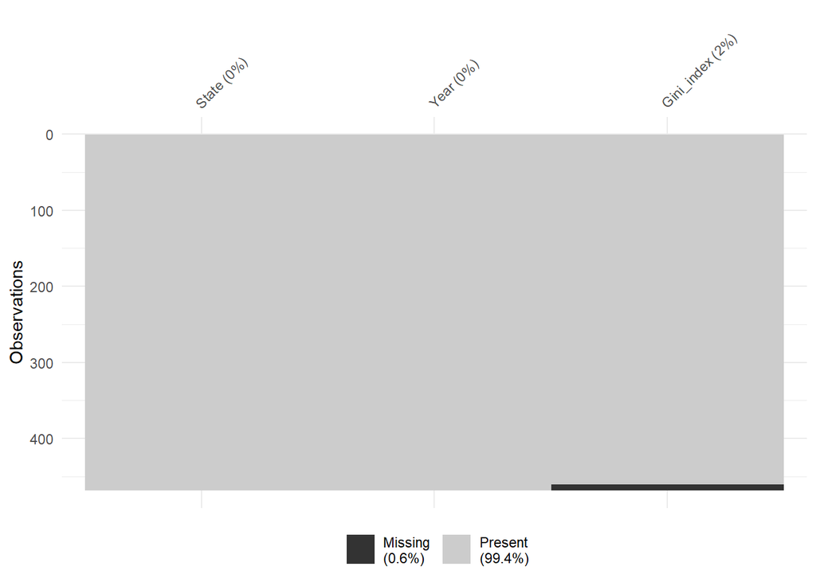

```r
# Plots
vis_miss(gr_long, cluster = TRUE)
```

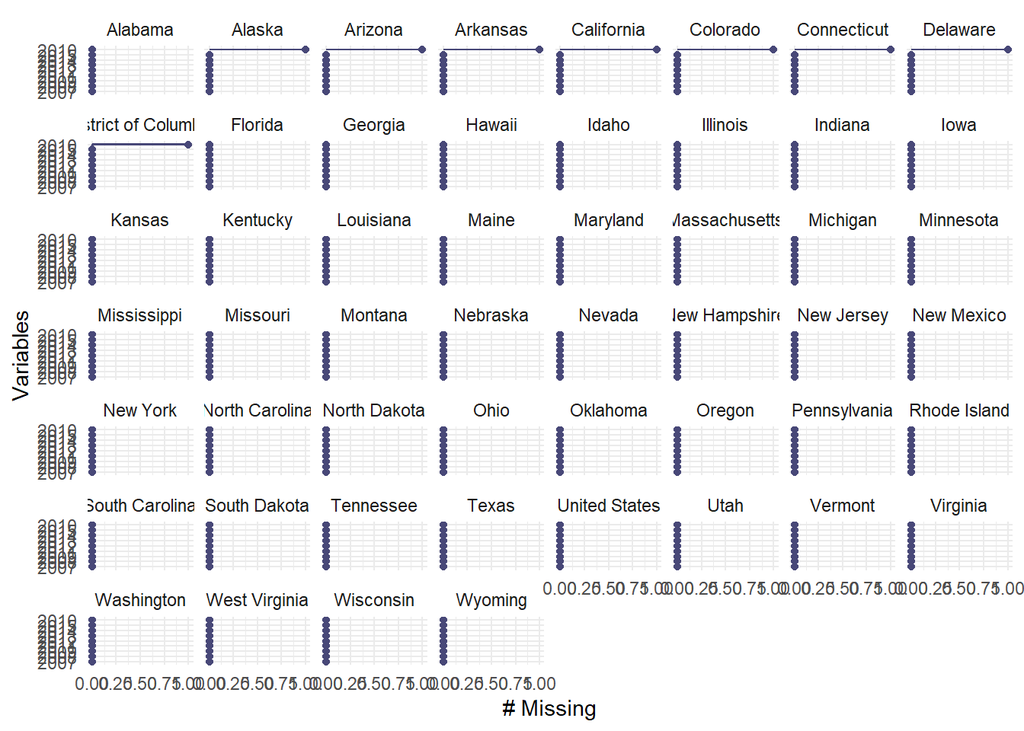

```r
gg_miss_var(gr, facet = State)
```

# Check outliers

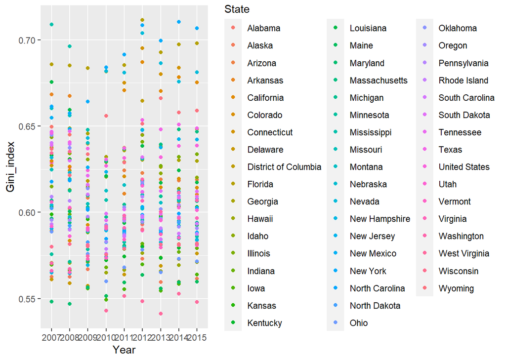

```r
gr_long %>%
  ggplot(aes(x = Year,
             y = Gini_index,
             color = State)) +
 geom_point()
```

# Repalce NA and outlier

```r
gd_remove_outlier <- gd_long %>%
  mutate(Gini_index = ifelse(Gini_index == 1000, NA, Gini_index))
gd_cleaned <-  gd_remove_outlier %>%
  mutate(Gini_index = impute_mean(Gini_index))

gr_cleaned <-  gr_long %>%
  mutate(Gini_index = impute_mean(Gini_index))
```

# PCA

No need to standardize as the variables are measured in the same units.

```r
gd_cleaned_wide <-  gd_cleaned %>%
  pivot_wider(names_from = Year,
              values_from = Gini_index)

gd_cleaned_wide %>%
  column_to_rownames('State') %>%
  prcomp(scale.= FALSE) -> gd_pca
summary(gd_pca)
```

```
## Importance of components:
##                           PC1     PC2     PC3     PC4     PC5     PC6     PC7
## Standard deviation     0.1916 0.06414 0.03155 0.02286 0.01789 0.01690 0.01329
## Proportion of Variance 0.8392 0.09405 0.02275 0.01195 0.00732 0.00653 0.00404
## Cumulative Proportion  0.8392 0.93322 0.95597 0.96792 0.97524 0.98176 0.98580
##                            PC8     PC9    PC10     PC11    PC12     PC13
## Standard deviation     0.01251 0.01041 0.01006 0.008512 0.00801 0.006361
## Proportion of Variance 0.00358 0.00248 0.00232 0.001660 0.00147 0.000920
## Cumulative Proportion  0.98938 0.99186 0.99417 0.995830 0.99729 0.998220
##                            PC14     PC15     PC16      PC17
## Standard deviation     0.005742 0.005154 0.004286 6.974e-09
## Proportion of Variance 0.000750 0.000610 0.000420 0.000e+00
## Cumulative Proportion  0.998970 0.999580 1.000000 1.000e+00
```

PC1 has the largest standard deviation, which means it captures the most variability in the data, and subsequent PCs capture progressively less variability. PC1 explains the largest proportion of variance (0.8392), which means it retains most of the information in the original data. The cumulative proportion reaches 0.99417 after PC10, indicating that the first 10 PCs capture approximately 99.4% of the total variance.

```r
gr_cleaned_wide <-  gr_cleaned %>%
  pivot_wider(names_from = Year,
              values_from = Gini_index)

gr_cleaned_wide %>%
  column_to_rownames('State') %>%
  prcomp(scale.= FALSE) -> gr_pca
summary(gr_pca)
```

```
## Importance of components:
##                            PC1     PC2     PC3      PC4      PC5      PC6
## Standard deviation     0.09126 0.04468 0.01441 0.006567 0.006101 0.004072
## Proportion of Variance 0.78209 0.18749 0.01951 0.004050 0.003500 0.001560
## Cumulative Proportion  0.78209 0.96958 0.98910 0.993150 0.996640 0.998200
##                             PC7      PC8      PC9
## Standard deviation     0.003128 0.002608 0.001608
## Proportion of Variance 0.000920 0.000640 0.000240
## Cumulative Proportion  0.999120 0.999760 1.000000
```

PC1 has the highest standard deviation (0.09126), indicating that it captures the most variability in the data. Proportion of variance explained by the first PC alone is 78.21%, proportion of variance explained by the second PC alone is 18.75%. The cumulative proportion increases as you move through the PCs. This indicates that PC1 alone captures 78.21% of the total variance, PC1 and PC2 together capture 96.96%

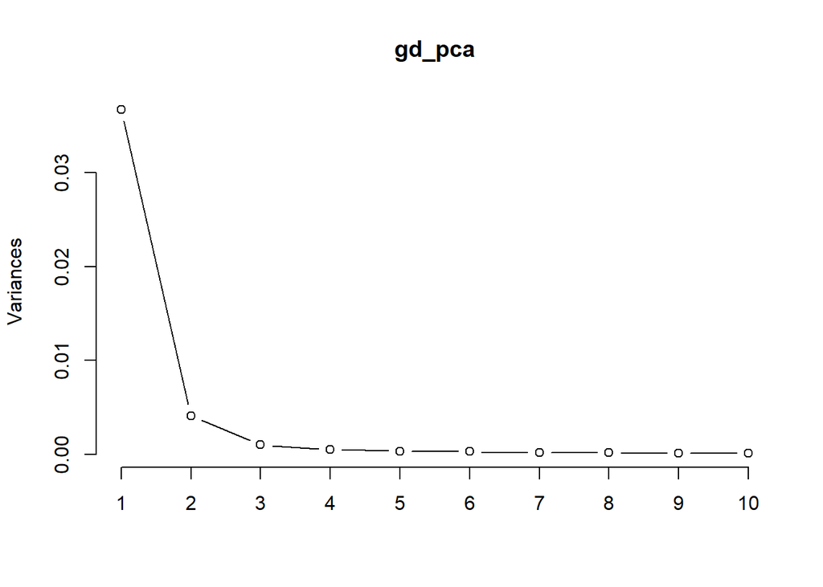

```r
screeplot(gd_pca,type = 'lines')
```

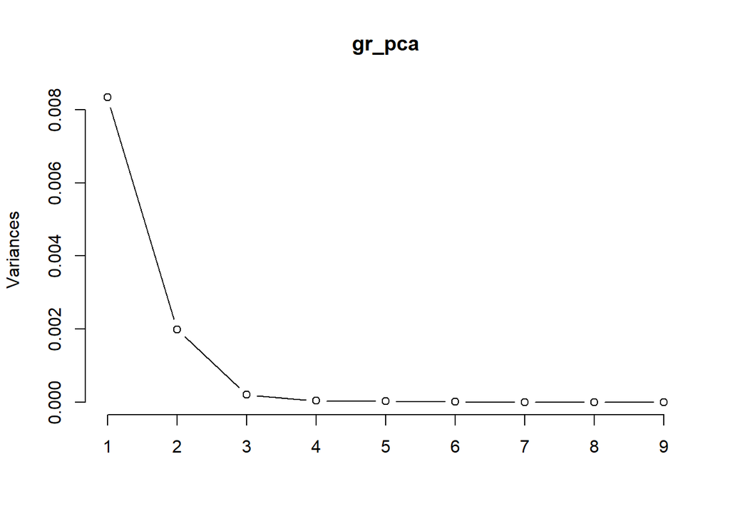

```r
screeplot(gr_pca,type = 'lines')
```

The elbow appears at the second PC, therefore 2 PCs should be used.

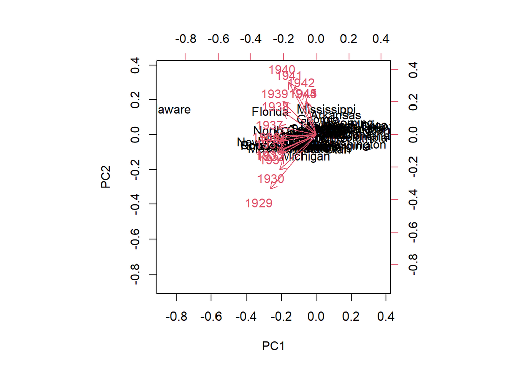

```r
biplot(gd_pca,scale=0)
```

It seems that 1942 and 1945 have a strong positive association with one another.

There is no strong negative associations.

1938 and 1929 are only weakly associated with another.

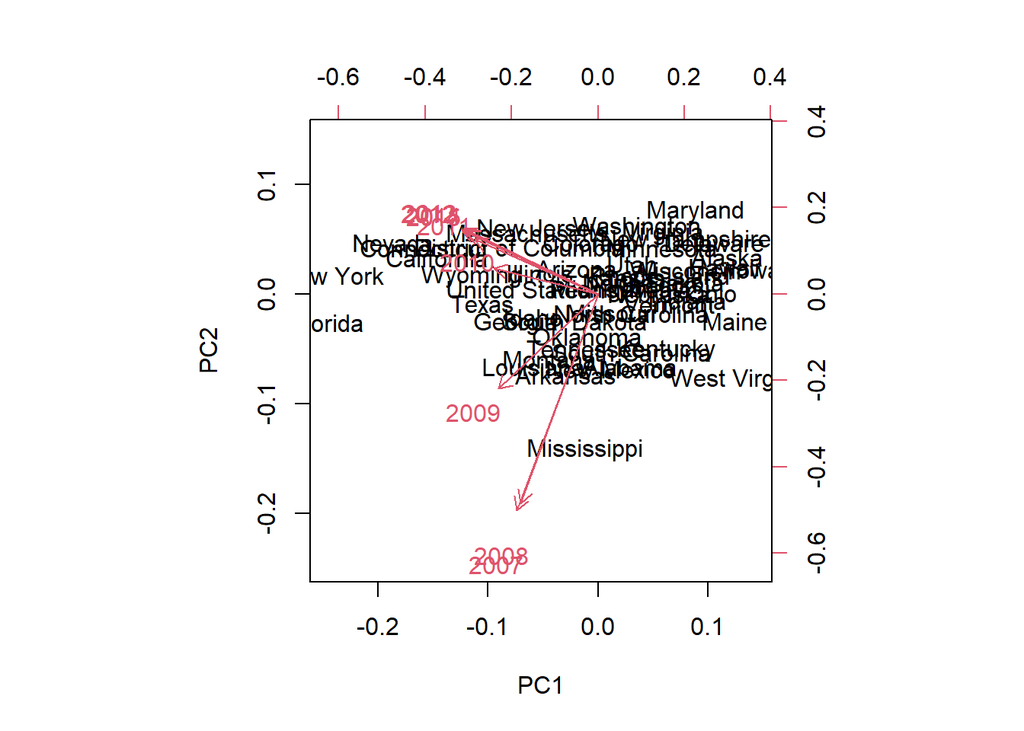

```r
biplot(gr_pca,scale=0) # variables clustered out of cluster/correlations/observations + event years(1929-1939/1940-1945)
```

2007 and 2008/2011, 2012 and 2015 have a strong positive association with one another.

There is no strong negative associations.

2008 and 2011 are only weakly associated with another.

# Factor Model

```r
gd_cleaned_wide %>%
  column_to_rownames('State') %>%
  factanal(factors = 10,rotation = 'none',scores = 'Bartlett')->gd_fa
cor(gd_fa$scores)
```

```
##                Factor1       Factor2       Factor3       Factor4       Factor5
## Factor1   1.000000e+00 -1.644187e-15  5.278956e-16 -5.191635e-16 -3.089332e-16
## Factor2  -1.644187e-15  1.000000e+00 -3.342929e-16 -9.965341e-16 -1.903745e-17
## Factor3   5.278956e-16 -3.342929e-16  1.000000e+00 -2.671426e-16  3.878621e-17
## Factor4  -5.191635e-16 -9.965341e-16 -2.671426e-16  1.000000e+00  4.171849e-15
## Factor5  -3.089332e-16 -1.903745e-17  3.878621e-17  4.171849e-15  1.000000e+00
## Factor6  -1.481668e-15  3.354072e-16  1.508279e-16 -4.210161e-15 -3.082270e-16
## Factor7  -9.982158e-16 -2.031836e-15  8.604698e-16  7.029858e-15 -1.661032e-15
## Factor8   2.383897e-15  1.477181e-16  5.990111e-16 -7.506099e-15  4.194805e-17
## Factor9  -1.423047e-15  2.853712e-16  2.992857e-15 -6.568744e-15  8.807807e-16
## Factor10 -4.241185e-17  2.659115e-15 -1.506722e-15 -4.974925e-15 -2.009836e-15
##                Factor6       Factor7       Factor8       Factor9      Factor10
## Factor1  -1.481668e-15 -9.982158e-16  2.383897e-15 -1.423047e-15 -4.241185e-17
## Factor2   3.354072e-16 -2.031836e-15  1.477181e-16  2.853712e-16  2.659115e-15
## Factor3   1.508279e-16  8.604698e-16  5.990111e-16  2.992857e-15 -1.506722e-15
## Factor4  -4.210161e-15  7.029858e-15 -7.506099e-15 -6.568744e-15 -4.974925e-15
## Factor5  -3.082270e-16 -1.661032e-15  4.194805e-17  8.807807e-16 -2.009836e-15
## Factor6   1.000000e+00  7.340543e-15  3.629666e-15 -6.904501e-15 -1.589543e-15
## Factor7   7.340543e-15  1.000000e+00  7.705079e-15 -2.084680e-15  5.749965e-15
## Factor8   3.629666e-15  7.705079e-15  1.000000e+00 -3.948491e-15 -5.790539e-15
## Factor9  -6.904501e-15 -2.084680e-15 -3.948491e-15  1.000000e+00  8.034720e-15
## Factor10 -1.589543e-15  5.749965e-15 -5.790539e-15  8.034720e-15  1.000000e+00
```

```r
gr_cleaned_wide %>%
  column_to_rownames('State') %>%
  factanal(factors = 5,rotation = 'none',scores = 'Bartlett')->gr_fa
cor(gr_fa$scores)
```

```
##               Factor1       Factor2       Factor3       Factor4       Factor5
## Factor1  1.000000e+00  4.916021e-16 -3.631861e-16  2.177890e-15 -1.183210e-15
## Factor2  4.916021e-16  1.000000e+00  1.734148e-16 -6.671465e-17  7.433204e-16
## Factor3 -3.631861e-16  1.734148e-16  1.000000e+00  6.078308e-15  6.950412e-16
## Factor4  2.177890e-15 -6.671465e-17  6.078308e-15  1.000000e+00 -1.155610e-14
## Factor5 -1.183210e-15  7.433204e-16  6.950412e-16 -1.155610e-14  1.000000e+00
```